# final_exam_23_prediction_cheung

Alex Cheung

2023-05-09

```r
library(tidymodels) # for modeling
library(tidyverse) # for general data wrangling
library(kableExtra) # for displaying formatted tables w/ kbl()
```

```r
library(purrr)  # for iteration using map() and walk() variants
library(janitor)  # for clean_names(), tabyl()
library(skimr) # for skim()
library(cowplot) # for plot_grid() and theme_half_open()
library(corrplot) #for bivariate correlations
library(conflicted) # for package conflicts
conflicts_prefer(yardstick::rmse)
```

```
## [conflicted] Will prefer yardstick::rmse over any other package.
```

```r
conflicts_prefer(dplyr::select)
```

```
## [conflicted] Will prefer dplyr::select over any other package.
```

```r
conflicts_prefer(dplyr::mutate)
```

```
## [conflicted] Will prefer dplyr::mutate over any other package.
```

```r
conflicts_prefer(dplyr::filter)
```

```
## [conflicted] Will prefer dplyr::filter over any other package.
```

```r
conflicts_prefer(broom::bootstrap)
```

```
## [conflicted] Will prefer broom::bootstrap over any other package.
```

```r
# data files path
path_final_exam_prediction <- "C:/Users/alexc/Documents/spring_2023_classes/psych_752/week_15"
```

```r
# fun modeling source
devtools::source_url("https://github.com/jjcurtin/lab_support/blob/main/fun_modeling.R?raw=true")
```

```
## ℹ SHA-1 hash of file is "7478d9bbd8aaa0296fa43b62a9e7cafb8ba936dc"
```

```r
devtools::source_url("https://github.com/jjcurtin/lab_support/blob/main/print_kbl.R?raw=true")
```

```
## ℹ SHA-1 hash of file is "021a7f7cddc1f0ffcd0613e57b94c81246b84f7b"
```

```r
# plotting theme
theme_set(theme_half_open())
```

```r
# parallel processing
library(doParallel)
n_core <- detectCores(logical = FALSE)
if(n_core > 2) {
  cl <- makePSOCKcluster(n_core - 1)
  registerDoParallel(cl)
}
```

# Cleaning EDA

## 1. Prep Data

```r
# reading in data and glimpse it
# satisfaction is outcome variable
data_all <- read_csv("airline_passenger_satisfaction.csv") %>%
  clean_names(case = "snake") %>%
  glimpse()
```

```
## Rows: 600
## Columns: 24
## $ id                                <dbl> 94031, 81130, 1431, 42411, 33339, 67…
## $ gender                            <chr> "Male", "Male", "Female", NA, "Femal…
## $ customer_type                     <chr> "Loyal Customer", "Loyal Customer", …
## $ age                               <dbl> 32, 18, 43, 53, 25, 58, 51, 42, 44, …
## $ type_of_travel                    <chr> "Business travel", "Business travel"…
## $ customer_class                    <chr> "Business", "Business", "Business", …
## $ flight_distance                   <dbl> 1389, 3456, 2899, 2694, 2419, 421, 3…
## $ inflight_wifi_service             <dbl> 2, 2, 0, 1, 5, 0, 5, 2, 1, 1, 2, 5, …
## $ departure_arrival_time_convenient <dbl> 2, 2, 0, 1, 5, 3, 5, 2, 1, 1, 2, 5, …
## $ ease_of_online_booking            <dbl> 2, 2, 0, 1, 5, 0, 5, 3, 1, 1, 2, 5, …
## $ gate_location                     <dbl> 2, 2, 5, 1, 5, 3, 5, 2, 1, 1, 2, 5, …
## $ food_and_drink                    <dbl> 5, 4, 4, 3, 5, 3, 4, 2, 2, 5, 5, 3, …
## $ online_boarding                   <dbl> 5, 4, 5, 5, 5, 3, 5, 4, 5, 5, 5, 5, …
## $ seat_comfort                      <dbl> 5, 4, 5, 4, 4, 3, 4, 4, 4, 5, 4, 5, …
## $ inflight_entertainment            <dbl> 5, 4, 2, 4, 5, 4, 4, 4, 5, 5, 4, 5, …
## $ onboard_service                   <dbl> 4, 4, 2, 4, 3, 4, 4, 4, 5, 3, 4, 5, …
## $ leg_room_service                  <dbl> 5, 2, 2, 4, 3, 0, 4, 4, 5, 1, 4, 5, …
## $ baggage_handling                  <dbl> 5, 1, 2, 4, 5, 4, 4, 4, 5, 3, 4, 5, …
## $ checkin_service                   <dbl> 5, 3, 3, 3, 3, 3, 3, 4, 3, 2, 5, 5, …
## $ inflight_service                  <dbl> 5, 3, 2, 4, 4, 4, 4, 4, 5, 4, 4, 5, …
## $ cleanliness                       <dbl> 5, 4, 4, 3, 5, 3, 5, 3, 4, 5, 5, 5, …
## $ departure_delay_in_minutes        <dbl> 67, 0, 6, 0, 3, 0, 0, 50, 8, 21, 21,…
## $ arrival_delay_in_minutes          <dbl> 79, 0, 0, 0, 2, 0, 0, 42, 5, 4, 7, 1…
## $ satisfaction                      <chr> "satisfied", "satisfied", "satisfied…
```

## 2. Checking for missing values

```r
# skimming data
data_all %>% skim_some()
```

Data summary

| Name | Piped data |
| --- | --- |
| Number of rows | 600 |
| Number of columns | 24 |
| _______________________ |  |
| Column type frequency: |  |
| character | 5 |
| numeric | 19 |
| ________________________ |  |
| Group variables | None |

**Variable type: character**

| skim_variable | n_missing | complete_rate | min | max | empty | n_unique | whitespace |
| --- | --- | --- | --- | --- | --- | --- | --- |
| gender | 117 | 0.80 | 4 | 6 | 0 | 2 | 0 |
| customer_type | 0 | 1.00 | 14 | 17 | 0 | 2 | 0 |
| type_of_travel | 0 | 1.00 | 15 | 15 | 0 | 2 | 0 |
| customer_class | 5 | 0.99 | 3 | 8 | 0 | 3 | 0 |
| satisfaction | 0 | 1.00 | 9 | 23 | 0 | 2 | 0 |

**Variable type: numeric**

| skim_variable | n_missing | complete_rate | p0 | p100 |
| --- | --- | --- | --- | --- |
| id | 0 | 1.00 | 324 | 129861 |
| age | 0 | 1.00 | 8 | 85 |
| flight_distance | 0 | 1.00 | 56 | 3989 |
| inflight_wifi_service | 0 | 1.00 | 0 | 5 |
| departure_arrival_time_convenient | 0 | 1.00 | 0 | 5 |
| ease_of_online_booking | 0 | 1.00 | 0 | 5 |
| gate_location | 0 | 1.00 | 1 | 5 |
| food_and_drink | 0 | 1.00 | 1 | 5 |
| online_boarding | 41 | 0.93 | 0 | 5 |
| seat_comfort | 0 | 1.00 | 1 | 5 |
| inflight_entertainment | 0 | 1.00 | 1 | 5 |
| onboard_service | 22 | 0.96 | 1 | 5 |
| leg_room_service | 0 | 1.00 | 0 | 5 |
| baggage_handling | 0 | 1.00 | 1 | 5 |
| checkin_service | 0 | 1.00 | 1 | 5 |
| inflight_service | 0 | 1.00 | 1 | 5 |
| cleanliness | 0 | 1.00 | 1 | 5 |
| departure_delay_in_minutes | 7 | 0.99 | 0 | 360 |
| arrival_delay_in_minutes | 3 | 1.00 | 0 | 409 |

*We see that there are missing values in gender and customer_class for character variables. We also see that there are missing values for online_boarding, onboard_service, departure_delay, and arrival_delay for numeric variables*

```r
# looking at missing values of online_boarding
data_all %>% filter(is.na(online_boarding)) %>%
  print_kbl()
```

| id | gender | customer_type | age | type_of_travel | customer_class | flight_distance | inflight_wifi_service | departure_arrival_time_convenient | ease_of_online_booking | gate_location | food_and_drink | online_boarding | seat_comfort | inflight_entertainment | onboard_service | leg_room_service | baggage_handling | checkin_service | inflight_service | cleanliness | departure_delay_in_minutes | arrival_delay_in_minutes | satisfaction |
| --- | --- | --- | --- | --- | --- | --- | --- | --- | --- | --- | --- | --- | --- | --- | --- | --- | --- | --- | --- | --- | --- | --- | --- |
| 775 | Female | Loyal Customer | 50 | Business travel | Business | 2731 | 4 | 4 | 4 | 4 | 3 | NA | 5 | 5 | 5 | 5 | 5 | 3 | 5 | 4 | 0 | 0 | satisfied |
| 324 | Male | Loyal Customer | 28 | Business travel | Business | 1087 | 1 | 1 | 3 | 1 | 5 | NA | 5 | 5 | 3 | 2 | 4 | 5 | 5 | 5 | 0 | 0 | satisfied |
| 87524 | NA | Loyal Customer | 21 | Business travel | Eco Plus | 1598 | 0 | 3 | 0 | 2 | 1 | NA | 1 | 1 | 4 | 5 | 3 | 3 | 3 | 1 | 0 | 5 | satisfied |
| 40551 | NA | disloyal Customer | 22 | Business travel | Eco | 1415 | 3 | 3 | 3 | 4 | 1 | NA | 2 | 1 | 1 | 1 | 5 | 5 | 2 | 1 | 0 | 0 | satisfied |
| 128428 | NA | Loyal Customer | 55 | Business travel | Business | 1491 | 4 | 4 | 4 | 4 | 3 | NA | 4 | 5 | 5 | 5 | 5 | 3 | 5 | 3 | 0 | 0 | satisfied |
| 111801 | Female | Loyal Customer | 39 | Business travel | Business | 1990 | 1 | 1 | 4 | 1 | 4 | NA | 5 | 3 | 3 | 4 | 3 | 4 | 3 | 3 | 0 | 11 | satisfied |
| 72242 | Male | Loyal Customer | 45 | Business travel | Business | 3640 | 3 | 3 | 3 | 3 | 5 | NA | 2 | 5 | 5 | 5 | 5 | 3 | 5 | 4 | 77 | 64 | satisfied |
| 104567 | NA | disloyal Customer | 24 | Business travel | Business | 731 | 0 | 0 | 0 | 3 | 1 | NA | 1 | 1 | 3 | 4 | 5 | 3 | 4 | 1 | 10 | 19 | satisfied |
| 93821 | Female | disloyal Customer | 85 | Business travel | Business | 67 | 4 | 4 | 4 | 3 | 4 | NA | 4 | 2 | 1 | 5 | 4 | 4 | 4 | 4 | 0 | 0 | satisfied |
| 28329 | Female | Loyal Customer | 51 | Business travel | Business | 2334 | 3 | 3 | 3 | 3 | 2 | NA | 4 | 5 | 5 | 5 | 5 | 3 | 5 | 4 | 28 | 12 | satisfied |
| 8441 | Male | Loyal Customer | 39 | Business travel | Business | 2024 | 1 | 1 | 1 | 1 | 4 | NA | 4 | 4 | 4 | 4 | 4 | 3 | 4 | 4 | 23 | 22 | satisfied |
| 91808 | Female | Loyal Customer | 49 | Business travel | Business | 2035 | 1 | 1 | 1 | 1 | 2 | NA | 4 | 3 | 3 | 3 | 3 | 3 | 3 | 4 | 0 | 0 | satisfied |
| 90085 | Male | Loyal Customer | 63 | Personal Travel | Eco | 371 | 4 | 3 | 4 | 4 | 3 | NA | 3 | 3 | 1 | 4 | 3 | 4 | 3 | 3 | 0 | 32 | satisfied |
| 48725 | Male | disloyal Customer | 20 | Business travel | Eco | 502 | 0 | 4 | 0 | 1 | 2 | NA | 4 | 2 | 5 | 4 | 5 | 3 | 5 | 2 | 0 | 0 | satisfied |
| 115189 | NA | Loyal Customer | 56 | Business travel | Eco | 331 | 4 | 3 | 2 | 2 | 4 | NA | 1 | 4 | 4 | 4 | 4 | 3 | 4 | 5 | 38 | 27 | satisfied |
| 111249 | Female | Loyal Customer | 59 | Business travel | Business | 1096 | 4 | 4 | 4 | 4 | 4 | NA | 4 | 4 | 4 | 4 | 4 | 3 | 4 | 3 | 0 | 0 | satisfied |
| 111635 | Male | Loyal Customer | 51 | Business travel | Business | 3876 | 0 | 0 | 0 | 3 | 2 | NA | 5 | 3 | 3 | 3 | 3 | 5 | 3 | 4 | 0 | 0 | satisfied |
| 15259 | Female | Loyal Customer | 19 | Business travel | Eco Plus | 1222 | 5 | 1 | 1 | 1 | 5 | NA | 5 | 5 | 1 | 4 | 5 | 1 | 1 | 5 | 0 | 0 | satisfied |
| 57503 | Male | Loyal Customer | 23 | Business travel | Business | 1504 | 5 | 5 | 5 | 5 | 4 | NA | 4 | 4 | 3 | 1 | 1 | 4 | 3 | 4 | 9 | 0 | satisfied |
| 45170 | NA | Loyal Customer | 28 | Personal Travel | Eco | 909 | 4 | 3 | 4 | 3 | 2 | NA | 2 | 2 | 4 | 4 | 3 | 1 | 3 | 2 | 66 | 62 | satisfied |
| 17127 | Male | Loyal Customer | 33 | Business travel | Business | 3153 | 0 | 5 | 0 | 4 | 3 | NA | 3 | 3 | 3 | 4 | 1 | 1 | 2 | 3 | 0 | 0 | satisfied |
| 49755 | Female | Loyal Customer | 29 | Business travel | Business | 2700 | 2 | 2 | 2 | 2 | 5 | NA | 5 | 5 | 2 | 3 | 2 | 3 | 4 | 5 | 0 | 0 | satisfied |
| 118099 | Male | Loyal Customer | 23 | Business travel | Eco | 680 | 4 | 2 | 2 | 2 | 4 | NA | 5 | 4 | 5 | 3 | 5 | 1 | 3 | 4 | 0 | 0 | satisfied |
| 68416 | Female | Loyal Customer | 45 | Business travel | Business | 1691 | 5 | 5 | 5 | 5 | 5 | NA | 5 | 4 | 4 | 4 | 4 | 3 | 4 | 4 | 0 | 0 | satisfied |
| 37337 | Female | Loyal Customer | 32 | Business travel | Business | 1725 | 5 | 5 | 5 | 5 | 2 | NA | 2 | 2 | 5 | 4 | 4 | 5 | 4 | 2 | 65 | 51 | satisfied |
| 36419 | Male | disloyal Customer | 24 | Business travel | Business | 228 | 4 | 3 | 4 | 2 | 2 | NA | 2 | 2 | 5 | 5 | 4 | 5 | 5 | 2 | 0 | 0 | satisfied |
| 61966 | NA | Loyal Customer | 32 | Business travel | Eco | 2541 | 5 | 5 | 5 | 5 | 5 | NA | 5 | 5 | 4 | 1 | 4 | 3 | 4 | 5 | 30 | 17 | satisfied |
| 87819 | Female | Loyal Customer | 59 | Business travel | Business | 2774 | 0 | 5 | 0 | 1 | 5 | NA | 4 | 3 | 3 | 3 | 3 | 5 | 3 | 4 | 0 | 1 | satisfied |
| 89351 | Female | Loyal Customer | 30 | Personal Travel | Eco | 860 | 3 | 5 | 3 | 2 | 2 | NA | 2 | 2 | 1 | 1 | 5 | 4 | 2 | 2 | 0 | 0 | neutral or dissatisfied |
| 49699 | Male | disloyal Customer | 39 | Business travel | Business | 611 | 2 | 2 | 2 | 2 | 4 | NA | 1 | 4 | 1 | 1 | 2 | 1 | 2 | 4 | 0 | 0 | neutral or dissatisfied |
| 103760 | Male | disloyal Customer | 15 | Business travel | Eco | 1024 | 2 | 2 | 2 | 4 | 5 | NA | 5 | 5 | 4 | 4 | 4 | 4 | 3 | 5 | 0 | 0 | neutral or dissatisfied |
| 54342 | Female | Loyal Customer | 54 | Personal Travel | Eco | 284 | 3 | 5 | 3 | 2 | 2 | NA | 5 | 1 | NA | 3 | 1 | 3 | 1 | 3 | 0 | 6 | neutral or dissatisfied |
| 61625 | NA | disloyal Customer | 23 | Business travel | Eco | 444 | 4 | 3 | 4 | 4 | 1 | NA | 1 | 1 | 4 | 5 | 3 | 4 | 4 | 1 | 0 | 6 | neutral or dissatisfied |
| 25111 | Male | Loyal Customer | 66 | Personal Travel | Eco | 933 | 4 | 4 | 4 | 1 | 2 | NA | 2 | 2 | 5 | 4 | 5 | 4 | 4 | 2 | 0 | 0 | neutral or dissatisfied |
| 59187 | Male | Loyal Customer | 24 | Business travel | Business | 2348 | 3 | 4 | 4 | 4 | 3 | NA | 3 | 3 | 1 | 3 | 1 | 3 | 2 | 3 | 8 | 17 | neutral or dissatisfied |
| 22752 | Female | Loyal Customer | 21 | Business travel | Business | 628 | 2 | 5 | 5 | 5 | 2 | NA | 2 | 2 | 1 | 1 | 4 | 4 | 4 | 2 | 1 | 8 | neutral or dissatisfied |
| 67058 | Female | Loyal Customer | 64 | Personal Travel | Eco | 405 | 3 | 4 | 3 | 4 | 5 | NA | 5 | 1 | 1 | 3 | 1 | 3 | 1 | 4 | 0 | 0 | neutral or dissatisfied |
| 83889 | Male | Loyal Customer | 68 | Personal Travel | Eco | 265 | 4 | 2 | 4 | 4 | 5 | NA | 5 | 5 | 4 | 5 | 2 | 2 | 3 | 5 | 0 | 1 | neutral or dissatisfied |
| 29109 | Female | Loyal Customer | 54 | Personal Travel | Eco | 544 | 2 | 4 | 2 | 3 | 2 | NA | 3 | 3 | 3 | 2 | 3 | 2 | 3 | 2 | 0 | 0 | neutral or dissatisfied |
| 1376 | Female | Loyal Customer | 66 | Personal Travel | Eco | 883 | 1 | 3 | 1 | 3 | 5 | NA | 4 | 5 | 5 | 1 | 5 | 2 | 5 | 3 | 44 | 52 | neutral or dissatisfied |
| 74953 | Male | Loyal Customer | 49 | Personal Travel | Eco | 972 | 2 | 5 | 2 | 5 | 5 | NA | 5 | 5 | 4 | 4 | 5 | 4 | 4 | 5 | 0 | 0 | neutral or dissatisfied |

```r
# looking at missing values for onboard_service
data_all %>% filter(is.na(onboard_service)) %>%
  print_kbl()
```

| id | gender | customer_type | age | type_of_travel | customer_class | flight_distance | inflight_wifi_service | departure_arrival_time_convenient | ease_of_online_booking | gate_location | food_and_drink | online_boarding | seat_comfort | inflight_entertainment | onboard_service | leg_room_service | baggage_handling | checkin_service | inflight_service | cleanliness | departure_delay_in_minutes | arrival_delay_in_minutes | satisfaction |
| --- | --- | --- | --- | --- | --- | --- | --- | --- | --- | --- | --- | --- | --- | --- | --- | --- | --- | --- | --- | --- | --- | --- | --- |
| 47538 | Male | Loyal Customer | 44 | Business travel | Eco | 788 | 5 | 5 | 4 | 4 | 5 | 5 | 5 | 5 | NA | 1 | 3 | 4 | 1 | 5 | 0 | 0 | satisfied |
| 108265 | Male | Loyal Customer | 50 | Business travel | Business | 3091 | 3 | 3 | 3 | 3 | 3 | 5 | 4 | 5 | NA | 5 | 5 | 5 | 5 | 4 | 0 | 0 | satisfied |
| 120499 | Male | Loyal Customer | 44 | Business travel | Business | 2052 | 2 | 2 | 2 | 2 | 4 | 4 | 4 | 5 | NA | 5 | 5 | 4 | 5 | 3 | 0 | 0 | satisfied |
| 115082 | Male | Loyal Customer | 50 | Business travel | Eco | 991 | 4 | 3 | 3 | 3 | 4 | 4 | 4 | 4 | NA | 1 | 2 | 4 | 4 | 4 | 0 | 33 | satisfied |
| 81275 | Male | Loyal Customer | 61 | Business travel | Business | 3502 | 3 | 3 | 3 | 3 | 2 | 3 | 3 | 5 | NA | 5 | 5 | 2 | 5 | 1 | 0 | 0 | satisfied |
| 90705 | Male | Loyal Customer | 38 | Business travel | Business | 282 | 0 | 0 | 0 | 1 | 5 | 5 | 4 | 3 | NA | 2 | 2 | 4 | 3 | 5 | 0 | 0 | satisfied |
| 53580 | NA | Loyal Customer | 40 | Business travel | Business | 2070 | 3 | 3 | 3 | 3 | 5 | 5 | 2 | 5 | NA | 4 | 5 | 5 | 5 | 4 | 20 | 14 | satisfied |
| 22284 | Female | Loyal Customer | 44 | Business travel | Business | 2253 | 0 | 0 | 0 | 4 | 3 | 5 | 4 | 5 | NA | 5 | 5 | 5 | 5 | 3 | 13 | 4 | satisfied |
| 11142 | NA | Loyal Customer | 53 | Business travel | Eco | 397 | 5 | 1 | 1 | 1 | 4 | 3 | 2 | 5 | NA | 5 | 5 | 5 | 5 | 1 | 0 | 0 | satisfied |
| 30311 | Female | Loyal Customer | 27 | Business travel | Business | 2420 | 1 | 1 | 1 | 1 | 5 | 5 | 5 | 5 | NA | 3 | 4 | 4 | 5 | 5 | 5 | 0 | satisfied |
| 9288 | Female | Loyal Customer | 25 | Business travel | Eco Plus | 1533 | 4 | 4 | 4 | 4 | 4 | 4 | 5 | 4 | NA | 4 | 1 | 5 | 1 | 4 | 0 | 6 | satisfied |
| 126455 | Female | Loyal Customer | 52 | Business travel | Business | 1718 | 1 | 1 | 1 | 1 | 3 | 5 | 5 | 5 | NA | 5 | 5 | 4 | 5 | 3 | 40 | 34 | satisfied |
| 71448 | Female | Loyal Customer | 40 | Business travel | Business | 2694 | 1 | 1 | 1 | 1 | 5 | 4 | 5 | 5 | NA | 5 | 5 | 3 | 5 | 4 | 0 | 0 | satisfied |
| 77755 | Female | disloyal Customer | 42 | Business travel | Eco | 811 | 2 | 1 | 1 | 1 | 1 | 1 | 1 | 1 | NA | 2 | 1 | 2 | 5 | 1 | 3 | 0 | neutral or dissatisfied |
| 44456 | Male | Loyal Customer | 10 | Personal Travel | Eco | 550 | 2 | 4 | 2 | 4 | 4 | 2 | 1 | 4 | NA | 1 | 3 | 4 | 3 | 4 | 0 | 0 | neutral or dissatisfied |
| 61317 | Female | Loyal Customer | 25 | Personal Travel | Eco | 980 | 4 | 3 | 4 | 4 | 2 | 4 | 2 | 2 | NA | 2 | 3 | 4 | 4 | 2 | 12 | 9 | neutral or dissatisfied |
| 54342 | Female | Loyal Customer | 54 | Personal Travel | Eco | 284 | 3 | 5 | 3 | 2 | 2 | NA | 5 | 1 | NA | 3 | 1 | 3 | 1 | 3 | 0 | 6 | neutral or dissatisfied |
| 6918 | Male | Loyal Customer | 31 | Personal Travel | Eco Plus | 1067 | 3 | 4 | 3 | 2 | 4 | 3 | 4 | 4 | NA | 3 | 5 | 3 | 4 | 4 | 0 | 10 | neutral or dissatisfied |
| 108446 | Male | Loyal Customer | 33 | Business travel | Business | 468 | 1 | 5 | 5 | 5 | 1 | 1 | 1 | 1 | NA | 1 | 4 | 3 | 3 | 1 | 0 | 0 | neutral or dissatisfied |
| 64376 | Female | Loyal Customer | 22 | Personal Travel | Eco | 956 | 3 | 5 | 3 | 1 | 4 | 3 | 4 | 4 | NA | 5 | 4 | 5 | 4 | 4 | 2 | 0 | neutral or dissatisfied |
| 63160 | NA | Loyal Customer | 22 | Personal Travel | Eco | 250 | 2 | 5 | 2 | 2 | 3 | 2 | 3 | 3 | NA | 4 | 4 | 5 | 5 | 3 | 0 | 0 | neutral or dissatisfied |
| 15285 | Female | Loyal Customer | 24 | Business travel | Eco Plus | 259 | 2 | 4 | 4 | 4 | 2 | 2 | 3 | 2 | NA | 2 | 3 | 1 | 3 | 2 | 0 | 0 | neutral or dissatisfied |

## 3. Exploring Min/Max of Numeric Variables

```r
data_all %>%
  dplyr::select(where(is.numeric)) %>%
  skim_some()
```

Data summary

| Name | Piped data |
| --- | --- |
| Number of rows | 600 |
| Number of columns | 19 |
| _______________________ |  |
| Column type frequency: |  |
| numeric | 19 |
| ________________________ |  |
| Group variables | None |

**Variable type: numeric**

| skim_variable | n_missing | complete_rate | p0 | p100 |
| --- | --- | --- | --- | --- |
| id | 0 | 1.00 | 324 | 129861 |
| age | 0 | 1.00 | 8 | 85 |
| flight_distance | 0 | 1.00 | 56 | 3989 |
| inflight_wifi_service | 0 | 1.00 | 0 | 5 |
| departure_arrival_time_convenient | 0 | 1.00 | 0 | 5 |
| ease_of_online_booking | 0 | 1.00 | 0 | 5 |
| gate_location | 0 | 1.00 | 1 | 5 |
| food_and_drink | 0 | 1.00 | 1 | 5 |
| online_boarding | 41 | 0.93 | 0 | 5 |
| seat_comfort | 0 | 1.00 | 1 | 5 |
| inflight_entertainment | 0 | 1.00 | 1 | 5 |
| onboard_service | 22 | 0.96 | 1 | 5 |
| leg_room_service | 0 | 1.00 | 0 | 5 |
| baggage_handling | 0 | 1.00 | 1 | 5 |
| checkin_service | 0 | 1.00 | 1 | 5 |
| inflight_service | 0 | 1.00 | 1 | 5 |
| cleanliness | 0 | 1.00 | 1 | 5 |
| departure_delay_in_minutes | 7 | 0.99 | 0 | 360 |
| arrival_delay_in_minutes | 3 | 1.00 | 0 | 409 |

*I notice something interesting for online_boarding and onboard_service. If we take a look at online_boarding, the range is from 0-5, but the range for onboard_service is from 1-5. That tells me that the 0 might mean not applicable and that NAs actually are 0s.*

```r
data_all <- data_all %>%
   mutate(online_boarding = replace_na(online_boarding, 0))

data_all <- data_all %>%
   mutate(onboard_service = replace_na(onboard_service, 0))

data_all %>% skim_some()
```

Data summary

| Name | Piped data |
| --- | --- |
| Number of rows | 600 |
| Number of columns | 24 |
| _______________________ |  |
| Column type frequency: |  |
| character | 5 |
| numeric | 19 |
| ________________________ |  |
| Group variables | None |

**Variable type: character**

| skim_variable | n_missing | complete_rate | min | max | empty | n_unique | whitespace |
| --- | --- | --- | --- | --- | --- | --- | --- |
| gender | 117 | 0.80 | 4 | 6 | 0 | 2 | 0 |
| customer_type | 0 | 1.00 | 14 | 17 | 0 | 2 | 0 |
| type_of_travel | 0 | 1.00 | 15 | 15 | 0 | 2 | 0 |
| customer_class | 5 | 0.99 | 3 | 8 | 0 | 3 | 0 |
| satisfaction | 0 | 1.00 | 9 | 23 | 0 | 2 | 0 |

**Variable type: numeric**

| skim_variable | n_missing | complete_rate | p0 | p100 |
| --- | --- | --- | --- | --- |
| id | 0 | 1.00 | 324 | 129861 |
| age | 0 | 1.00 | 8 | 85 |
| flight_distance | 0 | 1.00 | 56 | 3989 |
| inflight_wifi_service | 0 | 1.00 | 0 | 5 |
| departure_arrival_time_convenient | 0 | 1.00 | 0 | 5 |
| ease_of_online_booking | 0 | 1.00 | 0 | 5 |
| gate_location | 0 | 1.00 | 1 | 5 |
| food_and_drink | 0 | 1.00 | 1 | 5 |
| online_boarding | 0 | 1.00 | 0 | 5 |
| seat_comfort | 0 | 1.00 | 1 | 5 |
| inflight_entertainment | 0 | 1.00 | 1 | 5 |
| onboard_service | 0 | 1.00 | 0 | 5 |
| leg_room_service | 0 | 1.00 | 0 | 5 |
| baggage_handling | 0 | 1.00 | 1 | 5 |
| checkin_service | 0 | 1.00 | 1 | 5 |
| inflight_service | 0 | 1.00 | 1 | 5 |
| cleanliness | 0 | 1.00 | 1 | 5 |
| departure_delay_in_minutes | 7 | 0.99 | 0 | 360 |
| arrival_delay_in_minutes | 3 | 1.00 | 0 | 409 |

*I corrected the NAs in online_boarding and onboard_service to 0 because 0 means not applicable following my reasoning in the previous step. I left departure_delay and arrival_delay alone because they seem to be actual missing values*

## 4. Exploring Responses of Categorical Variables

```r
data_all %>%
  select(where(is.character)) %>%
  walk2(.x = names(.),
        .y = .,
        .f = print_responses)
```

```
## gender: Male, Female
## customer_type: Loyal Customer, disloyal Customer
## type_of_travel: Business travel, Personal Travel
## customer_class: Business, Eco, Eco Plus
## satisfaction: satisfied, neutral or dissatisfied
```

```r
data_all <- data_all |>
  mutate(across(where(is.character), tidy_responses)) %>%
  glimpse()
```

```
## Rows: 600
## Columns: 24
## $ id                                <dbl> 94031, 81130, 1431, 42411, 33339, 67…
## $ gender                            <chr> "male", "male", "female", NA, "femal…
## $ customer_type                     <chr> "loyal_customer", "loyal_customer", …
## $ age                               <dbl> 32, 18, 43, 53, 25, 58, 51, 42, 44, …
## $ type_of_travel                    <chr> "business_travel", "business_travel"…
## $ customer_class                    <chr> "business", "business", "business", …
## $ flight_distance                   <dbl> 1389, 3456, 2899, 2694, 2419, 421, 3…
## $ inflight_wifi_service             <dbl> 2, 2, 0, 1, 5, 0, 5, 2, 1, 1, 2, 5, …
## $ departure_arrival_time_convenient <dbl> 2, 2, 0, 1, 5, 3, 5, 2, 1, 1, 2, 5, …
## $ ease_of_online_booking            <dbl> 2, 2, 0, 1, 5, 0, 5, 3, 1, 1, 2, 5, …
## $ gate_location                     <dbl> 2, 2, 5, 1, 5, 3, 5, 2, 1, 1, 2, 5, …
## $ food_and_drink                    <dbl> 5, 4, 4, 3, 5, 3, 4, 2, 2, 5, 5, 3, …
## $ online_boarding                   <dbl> 5, 4, 5, 5, 5, 3, 5, 4, 5, 5, 5, 5, …
## $ seat_comfort                      <dbl> 5, 4, 5, 4, 4, 3, 4, 4, 4, 5, 4, 5, …
## $ inflight_entertainment            <dbl> 5, 4, 2, 4, 5, 4, 4, 4, 5, 5, 4, 5, …
## $ onboard_service                   <dbl> 4, 4, 2, 4, 3, 4, 4, 4, 5, 3, 4, 5, …
## $ leg_room_service                  <dbl> 5, 2, 2, 4, 3, 0, 4, 4, 5, 1, 4, 5, …
## $ baggage_handling                  <dbl> 5, 1, 2, 4, 5, 4, 4, 4, 5, 3, 4, 5, …
## $ checkin_service                   <dbl> 5, 3, 3, 3, 3, 3, 3, 4, 3, 2, 5, 5, …
## $ inflight_service                  <dbl> 5, 3, 2, 4, 4, 4, 4, 4, 5, 4, 4, 5, …
## $ cleanliness                       <dbl> 5, 4, 4, 3, 5, 3, 5, 3, 4, 5, 5, 5, …
## $ departure_delay_in_minutes        <dbl> 67, 0, 6, 0, 3, 0, 0, 50, 8, 21, 21,…
## $ arrival_delay_in_minutes          <dbl> 79, 0, 0, 0, 2, 0, 0, 42, 5, 4, 7, 1…
## $ satisfaction                      <chr> "satisfied", "satisfied", "satisfied…
```

```r
data_all %>%
  select(where(is.character)) %>%
  walk2(.x = names(.),
        .y = .,
        .f = print_responses)
```

```
## gender: male, female
## customer_type: loyal_customer, disloyal_customer
## type_of_travel: business_travel, personal_travel
## customer_class: business, eco, eco_plus
## satisfaction: satisfied, neutral_or_dissatisfied
```

*The cleaned response labels look to be understandable and don’t need any more changing*

## 5.

Train/Test Splits

```r
set.seed(20110522)

splits <- data_all %>%
  initial_split(prop = .70, strata = "satisfaction")

data_trn <- analysis(splits)

data_test <- assessment(splits)
```

*I decided to do a train/test split of 70% because I felt that a 75% split would leave the test set having too few observations compared to the training set. I felt that it would lead to high variance in my model predictions later on*

# Modeling EDA

```r
data_trn %>%
  glimpse()
```

```
## Rows: 420
## Columns: 24
## $ id                                <dbl> 10046, 89351, 106347, 87171, 18881, …
## $ gender                            <chr> "male", "female", "male", NA, "femal…
## $ customer_type                     <chr> "loyal_customer", "loyal_customer", …
## $ age                               <dbl> 50, 30, 24, 38, 57, 49, 27, 53, 44, …
## $ type_of_travel                    <chr> "personal_travel", "personal_travel"…
## $ customer_class                    <chr> "eco", "eco", "eco", "business", "bu…
## $ flight_distance                   <dbl> 101, 860, 649, 261, 2665, 1013, 290,…
## $ inflight_wifi_service             <dbl> 3, 3, 3, 3, 2, 3, 2, 2, 4, 2, 1, 2, …
## $ departure_arrival_time_convenient <dbl> 5, 5, 2, 3, 2, 3, 2, 3, 2, 2, 1, 2, …
## $ ease_of_online_booking            <dbl> 3, 3, 3, 3, 2, 3, 2, 2, 2, 2, 1, 2, …
## $ gate_location                     <dbl> 5, 2, 2, 3, 2, 3, 3, 3, 2, 4, 3, 4, …
## $ food_and_drink                    <dbl> 2, 2, 4, 1, 3, 3, 4, 3, 4, 2, 2, 2, …
## $ online_boarding                   <dbl> 3, 0, 3, 4, 3, 4, 2, 2, 4, 3, 1, 2, …
## $ seat_comfort                      <dbl> 2, 2, 4, 3, 3, 3, 5, 2, 4, 3, 2, 2, …
## $ inflight_entertainment            <dbl> 2, 2, 4, 3, 2, 3, 4, 5, 4, 2, 2, 2, …
## $ onboard_service                   <dbl> 5, 1, 2, 3, 2, 3, 2, 5, 3, 1, 4, 4, …
## $ leg_room_service                  <dbl> 5, 1, 4, 3, 2, 3, 5, 2, 2, 4, 3, 2, …
## $ baggage_handling                  <dbl> 5, 5, 3, 3, 2, 3, 2, 5, 3, 4, 2, 3, …
## $ checkin_service                   <dbl> 4, 4, 1, 1, 1, 1, 4, 2, 3, 3, 4, 1, …
## $ inflight_service                  <dbl> 5, 2, 3, 3, 2, 3, 3, 5, 4, 1, 3, 4, …
## $ cleanliness                       <dbl> 2, 2, 4, 1, 1, 2, 4, 4, 4, 3, 2, 2, …
## $ departure_delay_in_minutes        <dbl> 0, 0, 19, 0, 22, 0, 0, 72, 15, 4, 0,…
## $ arrival_delay_in_minutes          <dbl> 1, 0, 30, 0, 11, 0, 0, 66, 27, 0, 2,…
## $ satisfaction                      <chr> "neutral_or_dissatisfied", "neutral_…
```

## Recipe for Modeling EDA

```r
rec <- recipe(satisfaction ~ ., data = data_trn) %>%
  step_rm(id) %>%
  step_string2factor(satisfaction, levels = c("neutral_or_dissatisfied", "satisfied")) %>%
  step_string2factor(all_of(c("gender", "customer_type", "type_of_travel"))) %>%
  step_string2factor(customer_class, ordered = TRUE, levels = c("eco", "eco_plus", "business"))
```

*In this recipe, I first decided to remove id because it does not have a strong prediction for the outcome and doesn’t tell us any meaningful information. I factorized all of the nominal predictors except for customer_class because it seems like it is an ordinal variable with three ordered levels.*

## Make feature matrix for EDA

```r
feat_trn <- rec %>%
  make_features(data_trn, data_trn) %>%
  glimpse()
```

```
## Rows: 420
## Columns: 23
## $ gender                            <fct> male, female, male, NA, female, NA, …
## $ customer_type                     <fct> loyal_customer, loyal_customer, disl…
## $ age                               <dbl> 50, 30, 24, 38, 57, 49, 27, 53, 44, …
## $ type_of_travel                    <fct> personal_travel, personal_travel, bu…
## $ customer_class                    <ord> eco, eco, eco, business, business, e…
## $ flight_distance                   <dbl> 101, 860, 649, 261, 2665, 1013, 290,…
## $ inflight_wifi_service             <dbl> 3, 3, 3, 3, 2, 3, 2, 2, 4, 2, 1, 2, …
## $ departure_arrival_time_convenient <dbl> 5, 5, 2, 3, 2, 3, 2, 3, 2, 2, 1, 2, …
## $ ease_of_online_booking            <dbl> 3, 3, 3, 3, 2, 3, 2, 2, 2, 2, 1, 2, …
## $ gate_location                     <dbl> 5, 2, 2, 3, 2, 3, 3, 3, 2, 4, 3, 4, …
## $ food_and_drink                    <dbl> 2, 2, 4, 1, 3, 3, 4, 3, 4, 2, 2, 2, …
## $ online_boarding                   <dbl> 3, 0, 3, 4, 3, 4, 2, 2, 4, 3, 1, 2, …
## $ seat_comfort                      <dbl> 2, 2, 4, 3, 3, 3, 5, 2, 4, 3, 2, 2, …
```

[output cut: 35 more lines]

## Categorical Variable Distributions

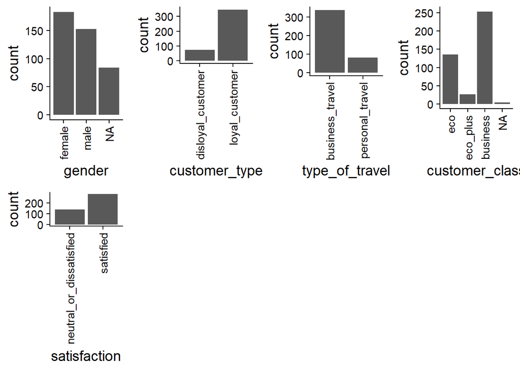

```r
# univariate
feat_trn %>%
  dplyr::select(where(is.factor)) %>%
  names() %>%
  map(~ plot_bar(x = .x, data = feat_trn)) %>%
  plot_grid(plotlist = ., ncol = 4)
```

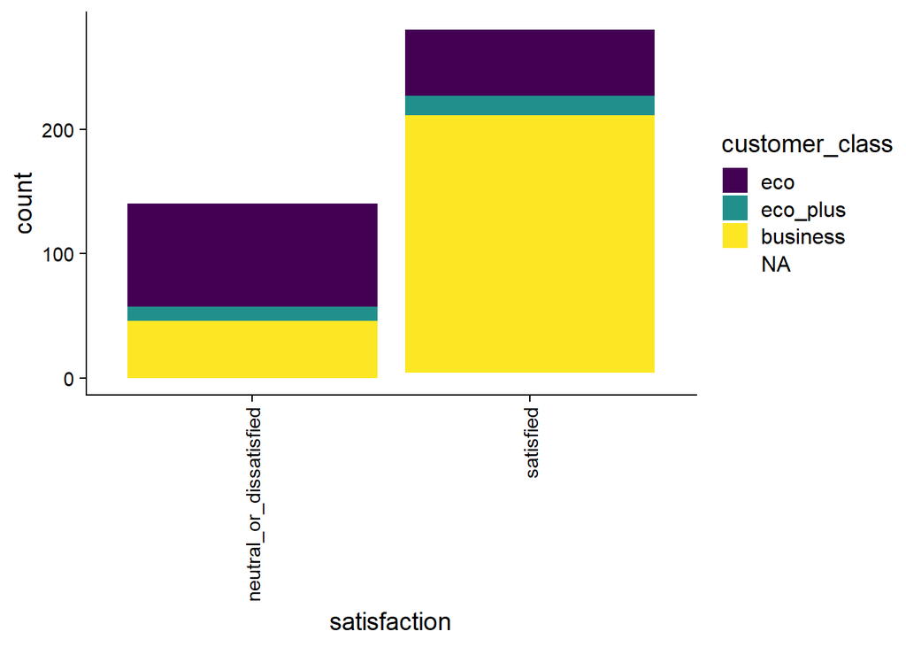

```r
# bivariate
feat_trn %>% plot_grouped_barplot_count("customer_class", "satisfaction")
```

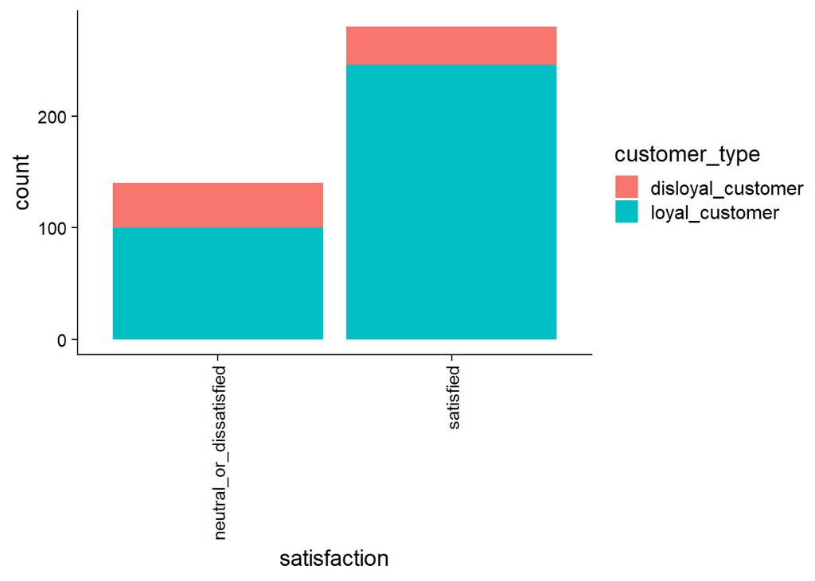

```r
feat_trn %>% plot_grouped_barplot_count("customer_type", "satisfaction")
```

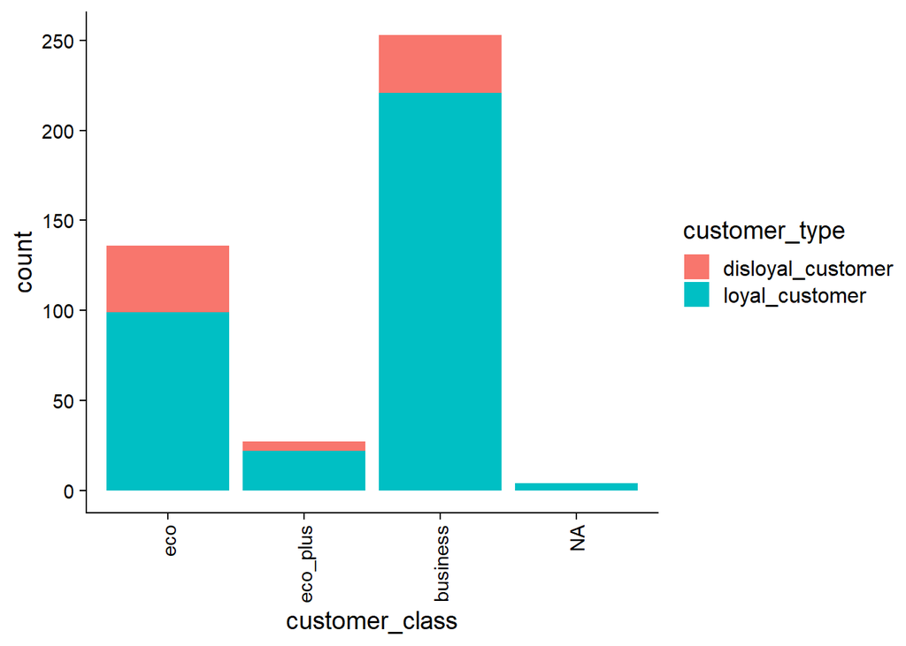

```r
feat_trn %>% plot_grouped_barplot_count("customer_type", "customer_class")
```

## Numeric Variable Distributions

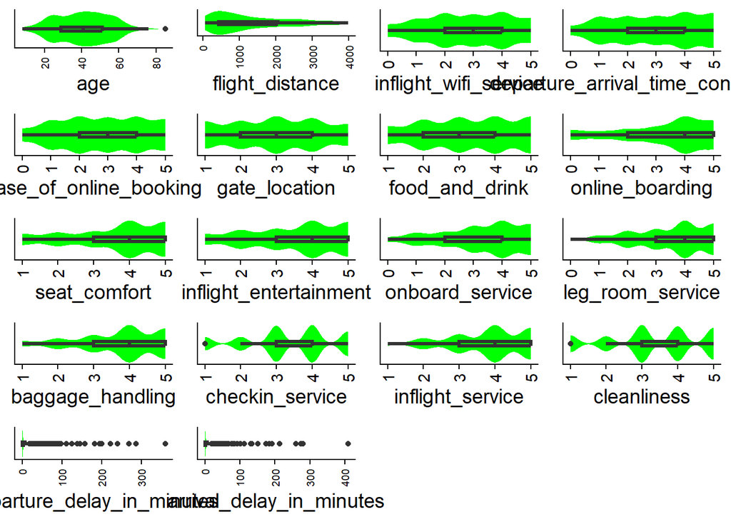

```r
# univariate
feat_trn %>%
  select(where(is.numeric)) %>%
  names() %>%
  map(~ plot_box_violin(x = .x, data = feat_trn)) %>%
  plot_grid(plotlist = ., ncol = 4)
```

[figure not shown]

```r
# bivariate
feat_trn %>%
  select(where(is.numeric)) %>%
  names() %>%
  map(~ plot_grouped_box_violin(data = data_trn, y = .x, x = "satisfaction")) %>%
  plot_grid(plotlist = ., ncol = 8)
```

# Fitting KNN Bootstrap Models

```r
set.seed (19990125)

splits_boot <- data_trn %>%
  bootstraps(times = 100, strata = "satisfaction")

splits_boot
```

```
## # Bootstrap sampling using stratification
## # A tibble: 100 × 2
##    splits            id
##    <list>            <chr>
##  1 <split [420/169]> Bootstrap001
##  2 <split [420/157]> Bootstrap002
##  3 <split [420/140]> Bootstrap003
##  4 <split [420/151]> Bootstrap004
##  5 <split [420/153]> Bootstrap005
##  6 <split [420/153]> Bootstrap006
##  7 <split [420/152]> Bootstrap007
##  8 <split [420/147]> Bootstrap008
##  9 <split [420/142]> Bootstrap009
## 10 <split [420/161]> Bootstrap010
## # ℹ 90 more rows
```

*I decided to just a bootstrap resampling method first because I was interested in getting a good baseline accuracy that can be compared later on. I thought that doing a single validation set approach wouldn’t really get the best accuracy since this is relatively small dataset and that can cause high variance with a 75/25 split.*

```r
# knn bootstrap recipe
rec_knn <- recipe(satisfaction ~ ., data = data_trn) %>%
  step_rm(id) %>%
  step_string2factor(satisfaction, levels = c("neutral_or_dissatisfied", "satisfied")) %>%
  step_string2factor(all_of(c("gender", "customer_type", "type_of_travel"))) %>%
  step_string2factor(customer_class, ordered = TRUE, levels = c("eco", "eco_plus", "business")) %>%
  step_impute_median(all_numeric_predictors()) %>%
  step_impute_mode(all_nominal_predictors()) %>%
  step_YeoJohnson(all_numeric_predictors()) %>%
  step_range(all_numeric_predictors()) %>%
  step_dummy(all_nominal_predictors())
```

*In the knn bootstrap recipe, I again decided to remove id as it does not provide much predictive power. I factorized the outcome variable of satisfaction with satsified being the second level. Addtionally, I factorized all nominal variables into unordered factors since they didn’t seem to be in any particular order. However, I made customer_class into an ordinal factor because it made sense that business would be high than both eco and eco plus. I imputed any missing data and range corrected numerical variables since KNN needs to range correct its features. Lastly, I dummy coded all nominal predictors.*

```r
# tuning hyperparamters (neighbors)
hyper_grid <- expand.grid(neighbors = seq(1, 50, by = 3))
hyper_grid
```

```
##    neighbors
## 1          1
## 2          4
## 3          7
## 4         10
## 5         13
## 6         16
## 7         19
## 8         22
## 9         25
## 10        28
## 11        31
## 12        34
## 13        37
## 14        40
## 15        43
## 16        46
## 17        49
```

```r
# fitting multiple bootstrap models
fits_knn_boot <-
  nearest_neighbor(neighbors = tune()) %>%
    set_engine("kknn") %>%
    set_mode("classification") %>%
    tune_grid(preprocessor = rec_knn, resamples = splits_boot, grid = hyper_grid,
              metrics = metric_set(accuracy))
```

```r
collect_metrics(fits_knn_boot, summarize = TRUE)
```

[output not shown]

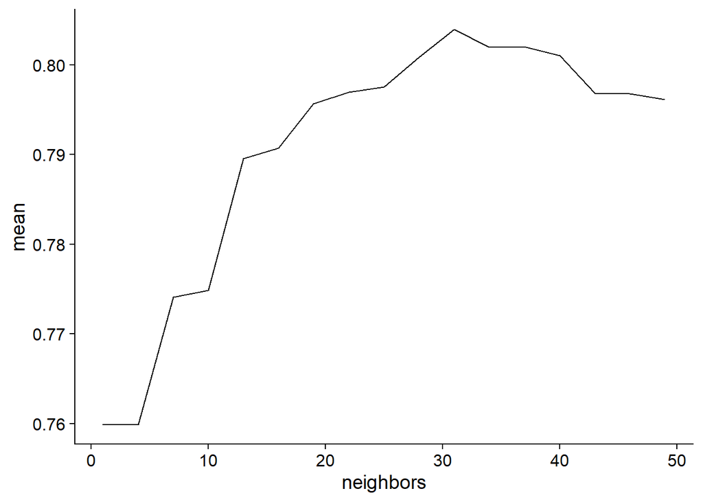

```r
# plotting performance
collect_metrics(fits_knn_boot, summarize = TRUE) %>%
  ggplot(aes(x = neighbors, y = mean)) +
    geom_line()
```

```r
# showing 10 best model configurations
show_best(fits_knn_boot, n = 10)
```

[output not shown]

```r
# showing the best mode configuration
select_best(fits_knn_boot)
```

```
## # A tibble: 1 × 2
##   neighbors .config
##       <dbl> <chr>
## 1        31 Preprocessor1_Model11
```

*The best model configuration was 31 neighbors*

# Fitting GLMnet Model

```r
# glmnet recipe
rec_glmnet <-
  recipe(satisfaction ~ ., data = data_trn) %>%
  step_rm(id) %>%
  step_string2factor(satisfaction, levels = c("neutral_or_dissatisfied", "satisfied")) %>%
  step_string2factor(all_of(c("gender", "customer_type", "type_of_travel"))) %>%
  step_string2factor(customer_class, ordered = TRUE, levels = c("eco", "eco_plus", "business")) %>%
  step_impute_median(all_numeric_predictors()) %>%
  step_impute_mode(all_nominal_predictors()) %>%
  step_YeoJohnson(all_numeric_predictors()) %>%
  step_normalize(all_numeric_predictors()) %>%
  step_dummy(all_nominal_predictors())
```

```r
# tuning grid
grid_glmnet <- expand_grid(penalty = exp(seq(-3, 1, length.out = 50)),
                           mixture = seq(0, 1, length.out = 6))
```

*I chose these hyperparameters because I wanted the penalty to be large so that the parameter estimates are reducted more. The length_out is 50 so that I can zoom in on the peak of performance, otherwise it would be hard to see.*

```r
# fitting glmnet models
fits_glmnet <-
   logistic_reg(penalty = tune(),
             mixture = tune()) %>%
  set_engine("glmnet") %>%
  set_mode("classification") %>%
  tune_grid(preprocessor = rec_glmnet,
            resamples = splits_boot, grid = grid_glmnet,
            metrics = metric_set(accuracy))
```

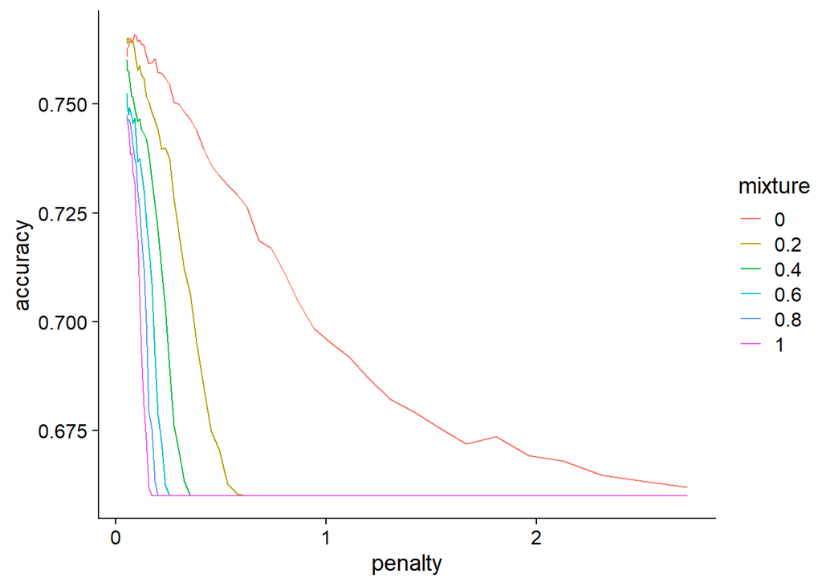

```r
# plotting model configurations
plot_hyperparameters(fits_glmnet, hp1 = "penalty", hp2 = "mixture", metric = "accuracy")
```

*The plot shows that accuracy peaks before penalty 1 but I cannot see it clearly, so I will modify my grid to show it more clearly. Now, since I changed the hyperparameters, we can see the peak of performance much more clearly.*

```r
# showing 10 best model configurations
collect_metrics(fits_glmnet, summarize = TRUE, n = 10)
```

[output not shown]

```r
# showing model with best hyperparameters
select_best(fits_glmnet)
```

```
## # A tibble: 1 × 3
##   penalty mixture .config
##     <dbl>   <dbl> <chr>
## 1  0.0882       0 Preprocessor1_Model008
```

*Here my best model configuration has a mixture of 0 meaning it is a Ridge regression model*

# Selecting my Best Model

```r
# creating feature matrices for selecting best model
feat_trn2 <- rec_knn %>%
  make_features(data_trn, data_trn, FALSE)

feat_test <- rec_knn %>%
  make_features(data_trn, data_test, FALSE)
```

*I decided to evaluate my best model using a train/test split because I wanted to see how it would perform with held out data in the test set.*

```r
# fit best model on full training sample
fit_knn_best <-
  nearest_neighbor(neighbors = select_best(fits_knn_boot)$neighbors) %>%
  set_engine("kknn") %>%
  set_mode("classification") %>%
  fit(satisfaction ~ ., data = feat_trn2)
```

# Evaluating Best Model

```r
# prediction accuracy on full test sample
accuracy_vec(feat_test$satisfaction, predict(fit_knn_best, feat_test)$.pred_class)
```

```
## [1] 0.8166667
```

*Accuracy in new data would be .816.*

# Summary

*During my processing of fitting models, I first decided to create feature training matrix to modeling EDA to get a sense of the relationship between predictor variables and the outcome. For my models, I did a KNN bootstrap resampling algorithm and a logistic regression resampling because they will give me low variance in my model performance compared to a simple independent test set split. The main changes I did to feature engineering was changing one nominal variable to an ordinal variable because it had levels and I felt that the hyperparameters I chose were good enough according to my plots. I chose to evaluate my best model performance which was a KNN bootstrap resampling model in a train/test split because I wanted to see how it would perform in a held out test set. I chose accuracy as my metric because it is a classification model. My model did not perform as well I expected, so maybe another model configuration would be needed for better accuracy in the future.*